# Tidy Tuesday #1 - School Diversity

Ethan Schacht

9/26/2019

# 1 **Introduction**

This is my first Tidy Tuesday data analysis! Every Tuesday, a new dataset is uploaded to this github repository (https://github.com/rfordatascience/tidytuesday) for aspiring data analysts and data scientists to practice from and gain insights from the data. I am relatively new to data analysis a young college student, though I believe these analyses will be very useful to people just getting started with the field, as it provides a good framework for exploring data. This week, I will be working with a school diversity dataset.

## 1.1 Loading Libraries and Data Import

```r
#load libraries

library(tidyverse)
library(stringi)
library(lubridate)
library(scales)
library(modelr)
library(reshape2)

diversity <- read_csv("https://raw.githubusercontent.com/rfordatascience/tidytuesday/master/data/2019/2019-09-24/school_diversity.csv")
head(diversity, 10)
```

```
## # A tibble: 10 x 15
##    LEAID LEA_NAME ST    d_Locale_Txt SCHOOL_YEAR   AIAN Asian  Black
##    <chr> <chr>    <chr> <chr>        <chr>        <dbl> <dbl>  <dbl>
##  1 0100… alabama… AL    <NA>         1994-1995   0      0.589 71.7
##  2 0100… albertv… AL    town-distant 1994-1995   0      0.321  1.28
##  3 0100… albertv… AL    town-distant 2016-2017   0.294  0.551  3.19
##  4 0100… marshal… AL    rural-dista… 1994-1995   0.104  0.134  0.373
##  5 0100… marshal… AL    rural-dista… 2016-2017   0.492  0.299  1.07
##  6 0100… hoover … AL    city-small   1994-1995   0.0652 1.60   6.04
##  7 0100… hoover … AL    city-small   2016-2017   0.0933 6.68  24.7
##  8 0100… madison… AL    suburban-la… 2016-2017   0.594  8.92  20.4
##  9 0100… leeds c… AL    suburban-la… 2016-2017   0.304  1.06  23.0
## 10 0100… boaz ci… AL    town-distant 2016-2017   0.502  1.17   1.97
## # … with 7 more variables: Hispanic <dbl>, White <dbl>, Multi <dbl>,
## #   Total <dbl>, diverse <chr>, variance <dbl>, int_group <chr>
```

It appears that the rows are arranged by state, and we can see multiple occurances of the school district name as there are different school years. This data is already pretty tidy but we will want a better idea of what each row represents.

# 2 Exploratory Data Analysis

## 2.1 Interpreting the Rows

Let’s arrange by school district name and school year to find out what each row tells us…

```r
diversity2 <- diversity %>%
  arrange(LEA_NAME, SCHOOL_YEAR)

head(diversity2, 20)
```

```
## # A tibble: 20 x 15
##    LEAID LEA_NAME ST    d_Locale_Txt SCHOOL_YEAR   AIAN   Asian  Black
##    <chr> <chr>    <chr> <chr>        <chr>        <dbl>   <dbl>  <dbl>
##  1 1700… a e r o… IL    <NA>         1994-1995   0       0       5.88
##  2 1700… a-c cen… IL    rural-dista… 1994-1995   0       0       0
##  3 1700… a-c cen… IL    rural-dista… 2016-2017   0       0       1.14
##  4 2700… a.c.g.c… MN    rural-dista… 2016-2017   1.11    0.492   0.123
##  5 4500… abbevil… SC    rural-dista… 1994-1995   0       0.0529 44.5
##  6 4500… abbevil… SC    rural-dista… 2016-2017   0.133   0.398  34.1
##  7 5500… abbotsf… WI    rural-fringe 1994-1995   0       0.149   0.297
##  8 5500… abbotsf… WI    rural-fringe 2016-2017   0.139   0.416   1.66
##  9 4807… abbott … TX    rural-dista… 1994-1995   0       0       2.17
## 10 4807… abbott … TX    rural-dista… 2016-2017   0       0       0.704
## 11 3602… abbott … NY    <NA>         1994-1995   0       0      70.6
## 12 0601… abc uni… CA    suburban-la… 1994-1995   0.217  38.1     9.69
## 13 0601… abc uni… CA    suburban-la… 2016-2017   0.285  37.4     8.63
## 14 1600… aberdee… ID    rural-dista… 2016-2017   0.962   0.275   0
## 15 2800… aberdee… MS    town-remote  1994-1995   0       0      71.9
## 16 2800… aberdee… MS    town-remote  2016-2017   0.0770  0.154  95.1
## 17 5300… aberdee… WA    town-remote  1994-1995   5.15    2.93    0.970
## 18 5300… aberdee… WA    town-remote  2016-2017   3.61    2.28    0.918
## 19 4602… aberdee… SD    town-remote  1994-1995   7.20    0.990   0.225
## 20 4602… aberdee… SD    town-remote  2016-2017   6.41    3.50    2.25
## # … with 7 more variables: Hispanic <dbl>, White <dbl>, Multi <dbl>,
## #   Total <dbl>, diverse <chr>, variance <dbl>, int_group <chr>
```

```r
table(diversity2$SCHOOL_YEAR)
```

```
##
## 1994-1995 2016-2017
##     14760     13184
```

## 2.2 Summarising the Data

```r
summary(diversity2)
```

```
##     LEAID             LEA_NAME              ST
##  Length:27944       Length:27944       Length:27944
##  Class :character   Class :character   Class :character
##  Mode  :character   Mode  :character   Mode  :character
##
##
##
##
##  d_Locale_Txt       SCHOOL_YEAR             AIAN
##  Length:27944       Length:27944       Min.   :  0.0000
##  Class :character   Class :character   1st Qu.:  0.0000
##  Mode  :character   Mode  :character   Median :  0.1566
##                                        Mean   :  2.7879
##                                        3rd Qu.:  0.6144
##                                        Max.   :100.0000
##
##      Asian              Black             Hispanic            White
##  Min.   : 0.00000   Min.   :  0.0000   Min.   :  0.0000   Min.   :  0.00
##  1st Qu.: 0.05818   1st Qu.:  0.2023   1st Qu.:  0.5505   1st Qu.: 65.24
##  Median : 0.53124   Median :  0.9231   Median :  2.7094   Median : 88.60
##  Mean   : 1.76956   Mean   :  6.5515   Mean   : 10.4520   Mean   : 76.93
##  3rd Qu.: 1.44514   3rd Qu.:  3.9649   3rd Qu.: 10.1256   3rd Qu.: 96.45
##  Max.   :74.90586   Max.   :100.0000   Max.   :100.0000   Max.   :100.00
##
##      Multi            Total           diverse             variance
##  Min.   : 0.000   Min.   :      1   Length:27944       Min.   :0.000
##  1st Qu.: 1.070   1st Qu.:    366   Class :character   1st Qu.:0.017
##  Median : 2.378   Median :   1044   Mode  :character   Median :0.046
##  Mean   : 3.202   Mean   :   3228                      Mean   :0.078
##  3rd Qu.: 4.174   3rd Qu.:   2720                      3rd Qu.:0.107
##  Max.   :85.308   Max.   :1020747                      Max.   :0.601
##  NA's   :14760                                         NA's   :24923
##   int_group
##  Length:27944
##  Class :character
##  Mode  :character
##
##
##
##
```

```r
paste("NA's in LEAID:", sum(is.na(diversity2$LEAID)))
```

```
## [1] "NA's in LEAID: 0"
```

```r
paste("NA's in LEA_NAME:", sum(is.na(diversity2$LEA_NAME)))
```

```
## [1] "NA's in LEA_NAME: 0"
```

```r
paste("NA's in ST:", sum(is.na(diversity2$ST)))
```

```
## [1] "NA's in ST: 0"
```

```r
paste("NA's in d_locale_Txt:", sum(is.na(diversity2$d_Locale_Txt)))
```

```
## [1] "NA's in d_locale_Txt: 2043"
```

```r
paste("NA's in SCHOOL_YEAR:", sum(is.na(diversity2$SCHOOL_YEAR)))
```

```
## [1] "NA's in SCHOOL_YEAR: 0"
```

Most of our numeric values are proportions of different races in each district for a given year. We also have other useful information such as the state, whether the surroundings of a district are rural, urban, a town, etc (d_locale_Txt), variance, and the degree to which a district is integrated.

## 2.3 Missing Values

From the summary, it also appears that there are NA’s in 4 columns: d_locale_txt, multi (multi-ethnic proportion of student population), variance, and integration group. There are 27,944 rows, so lets see the proportion of NA’s in each of these columns.

```r
rows = 27944

paste("NA proportion in multi column:", round(sum(is.na(diversity2$Multi)) / rows, 3))
```

```
## [1] "NA proportion in multi column: 0.528"
```

```r
paste("NA proportion in variance column:", round(sum(is.na(diversity2$variance)) / rows, 3))
```

```
## [1] "NA proportion in variance column: 0.892"
```

```r
paste("NA proportion in int_group column:",round(sum(is.na(diversity2$int_group)) / rows, 3))
```

```
## [1] "NA proportion in int_group column: 0.892"
```

```r
paste("NA proportion in d_locale_txt column:", round(sum(is.na(diversity2$d_Locale_Txt)) / rows, 3))
```

```
## [1] "NA proportion in d_locale_txt column: 0.073"
```

We can see that 52.8% of our values in the multi ethnic proprtion are missing values, and almost 90% of both variance and integration group are missing values! If we ever choose to analyze these variables, we won’t have much data. Let’s look at the integration and variance columns to verify that the positions of their missing and non-missing valies correspond.

```r
diversity2 %>%
  select(variance, int_group) %>%
  head(20)
```

```
## # A tibble: 20 x 2
##    variance int_group
##       <dbl> <chr>
##  1 NA       <NA>
##  2 NA       <NA>
##  3 NA       <NA>
##  4 NA       <NA>
##  5  0.0487  Highly integrated
##  6  0.140   Somewhat integrated
##  7 NA       <NA>
##  8 NA       <NA>
##  9 NA       <NA>
## 10 NA       <NA>
## 11 NA       <NA>
## 12  0.219   Not integrated
## 13  0.235   Not integrated
## 14 NA       <NA>
## 15  0.00787 Highly integrated
## 16 NA       <NA>
## 17 NA       <NA>
## 18  0.0189  Highly integrated
## 19 NA       <NA>
## 20 NA       <NA>
```

They do correspond. This is likely due to the fact that the integration variable is simply an interpretation of the variance in diversity.

## 2.4 Do our Proportions Add up to 100?

Let’s make sure our proportions of different racial groups add to approximately 100%, so we know we are working with data that is error-free. Note that most of our multi racial values are missing, so this may cause error.

```r
racial_groups <- diversity2 %>%
  select(6:11) %>%
  mutate(total_prop = if_else(is.na(Multi), AIAN + Asian + Black + Hispanic + White, AIAN + Asian + Black + Hispanic + White + Multi))

table(racial_groups$total_prop)
```

```
##
## 99.9999999999999              100
##             1915            26029
```

There appears to be no error in the data entry. The proportions add up to 100 even when the multi racial value is missing, so these missing values may simply be due to districts not providing a multi racial option in their surveys.

## 2.5 Variation

Our first visualizations should illustrate the distributions of individual variables…

### 2.5.1 Variation of Races

#### 2.5.1.1 American Indians / Native Alaskans

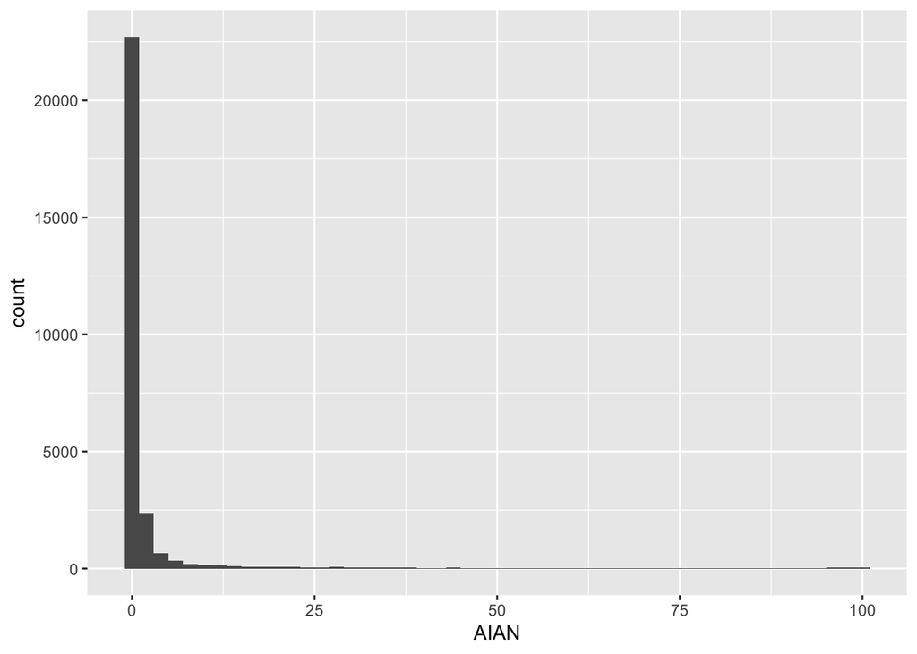

```r
diversity2 %>%
  ggplot(aes(AIAN)) +
    geom_histogram(binwidth = 2)
```

#### 2.5.1.2 Asian

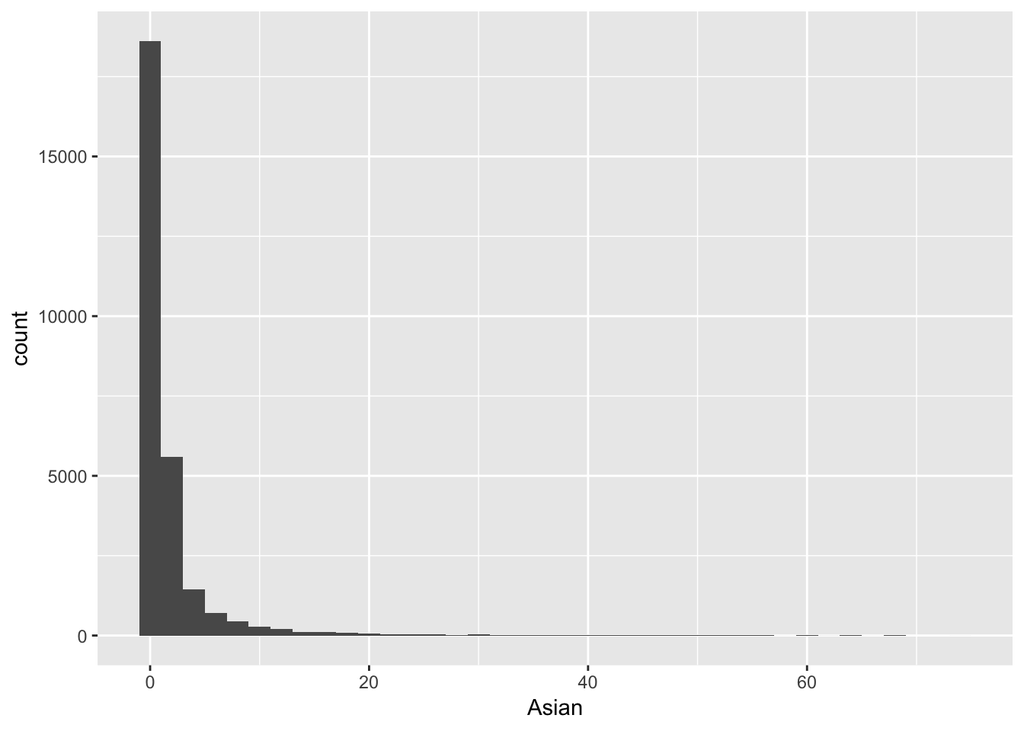

```r
diversity2 %>%
  ggplot(aes(Asian)) +
    geom_histogram(binwidth = 2)
```

#### 2.5.1.3 Black

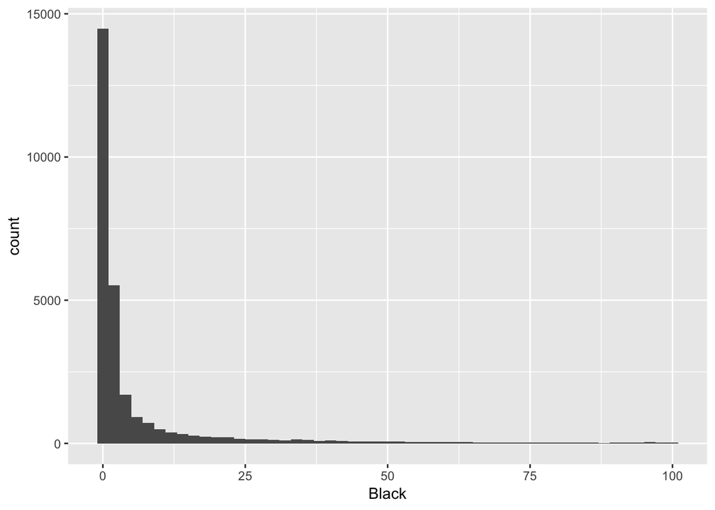

```r
diversity2 %>%
  ggplot(aes(Black)) +
    geom_histogram(binwidth = 2)
```

#### 2.5.1.4 Hispanic

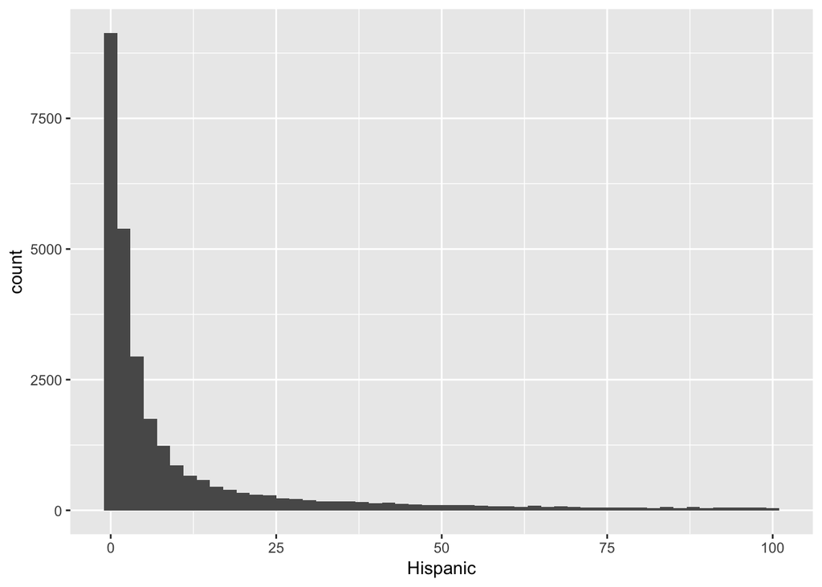

```r
diversity2 %>%
  ggplot(aes(Hispanic)) +
    geom_histogram(binwidth = 2)
```

#### 2.5.1.5 Multi

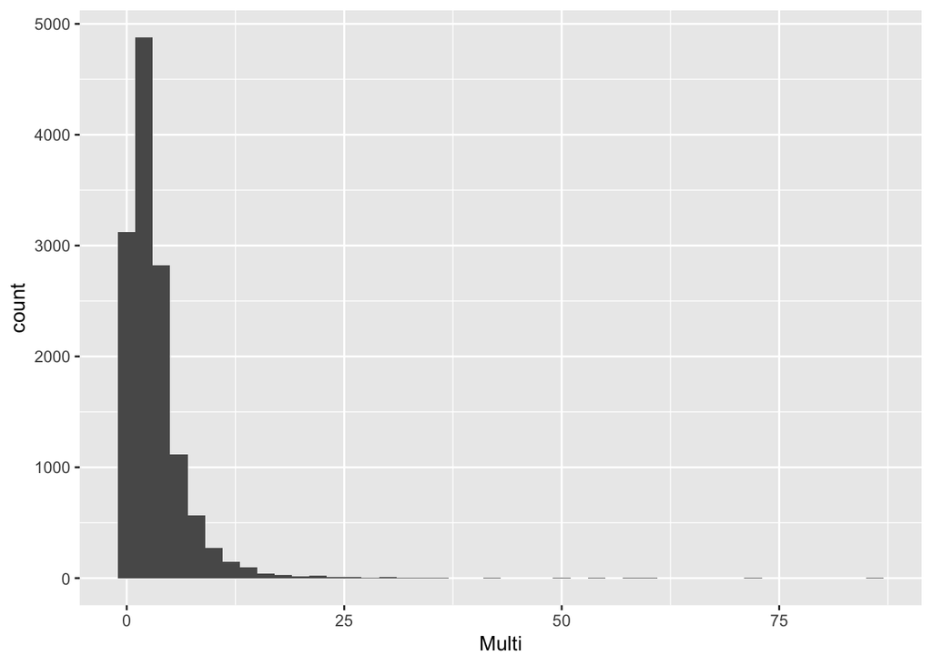

```r
diversity2 %>%
  ggplot(aes(Multi)) +
    geom_histogram(binwidth = 2)
```

#### 2.5.1.6 White

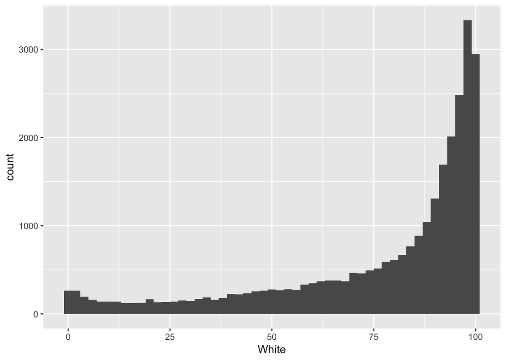

```r
diversity2 %>%
  ggplot(aes(White)) +
    geom_histogram(binwidth = 2)
```

The only distribution that is skewed to the left, meaning nearly all school districts have a white student majority. Hispanics appear to be the second most common race.

### 2.5.2 Other Variation

Let’s look at the distributions of some of our other variables…

#### 2.5.2.1 Student Body Count

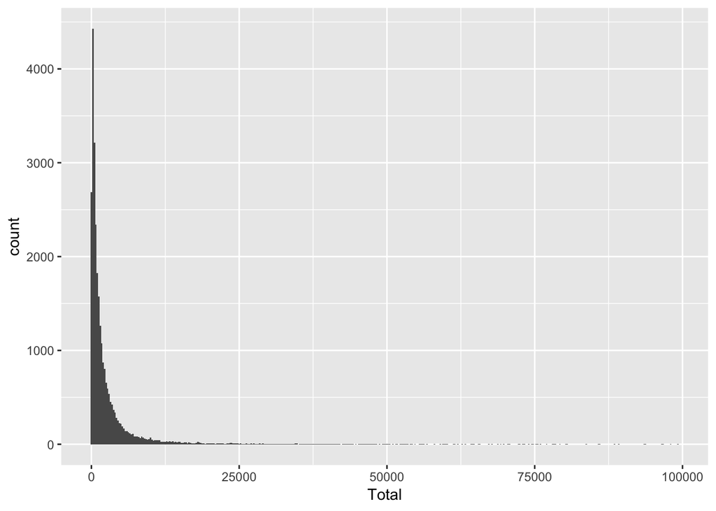

```r
total_arranged <- diversity2 %>%
  arrange(desc(Total)) %>%
  filter(Total < 100000)

total_arranged %>%
  ggplot(aes(Total)) +
    geom_histogram(binwidth = 250)
```

```r
diversity2 %>%
  arrange(desc(Total)) %>%
  filter(Total >= 100000) %>%
  select(LEA_NAME, SCHOOL_YEAR, Total)
```

```
## # A tibble: 47 x 3
##    LEA_NAME                     SCHOOL_YEAR   Total
##    <chr>                        <chr>         <dbl>
##  1 new york city public schools 1994-1995   1020747
##  2 new york city public schools 2016-2017    918514
##  3 los angeles unified          1994-1995    632631
##  4 los angeles unified          2016-2017    449387
##  5 city of chicago sd 299       1994-1995    405856
##  6 dade                         1994-1995    326848
##  7 city of chicago sd 299       2016-2017    319535
##  8 clark county school district 2016-2017    318418
##  9 dade                         2016-2017    291737
## 10 broward                      2016-2017    218485
## # … with 37 more rows
```

This distribution is skewed way to the right. I filtered out all of the districts with a student body count of greater than 100,000 to make the bins more visible, so I also created a table to schow all the districts with more than 100,000 students.

#### 2.5.2.2 States

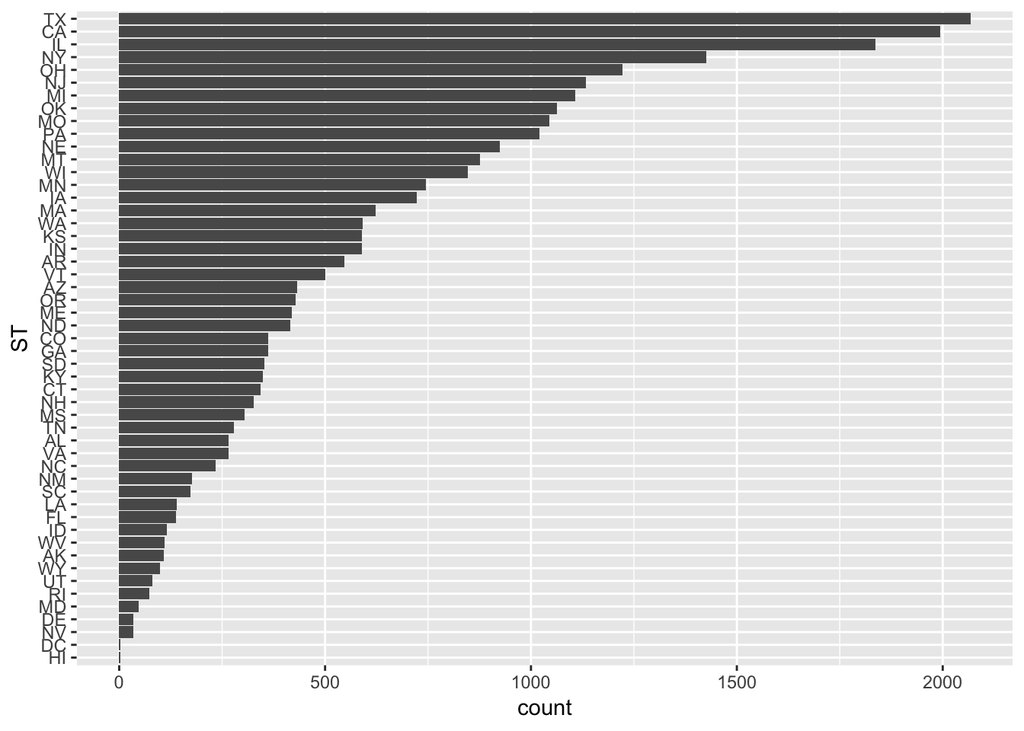

```r
diversity2 %>%
  mutate(ST = ST %>% fct_infreq() %>% fct_rev()) %>%
  ggplot(aes(ST)) +
    geom_bar() +
    coord_flip()
```

Texas, California, and Illinois contain the most occurances in the dataset. Keep in mind that most districts get a row for 1994-1995 and 2016-2017.

#### 2.5.2.3 Location Type

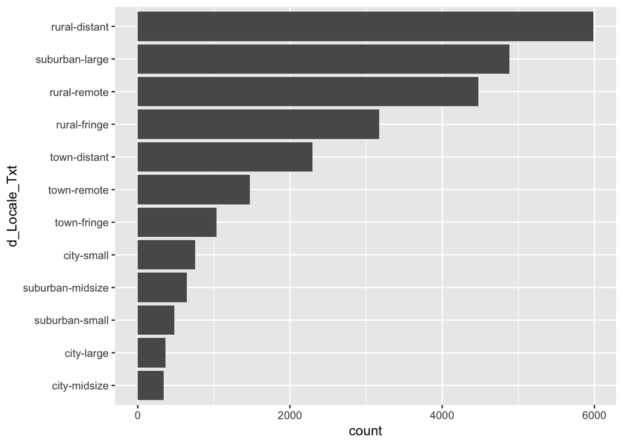

```r
diversity2 %>%
  mutate(d_Locale_Txt = d_Locale_Txt %>% fct_infreq() %>% fct_rev()) %>%
  filter(!is.na(d_Locale_Txt)) %>%
  ggplot(aes(d_Locale_Txt)) +
    geom_bar() +
    coord_flip()
```

Most districts in the combination of the school years 94-95 and 16-17 are in rural areas.

## 2.6 Covariation

Now lets look at the relationships between some of our variables…

### 2.6.1 Have Schools Become More Diverse?

Let’s compare the overall diversity of school districts in America from the 1994-1995 school year to the 2016-2017 school year.

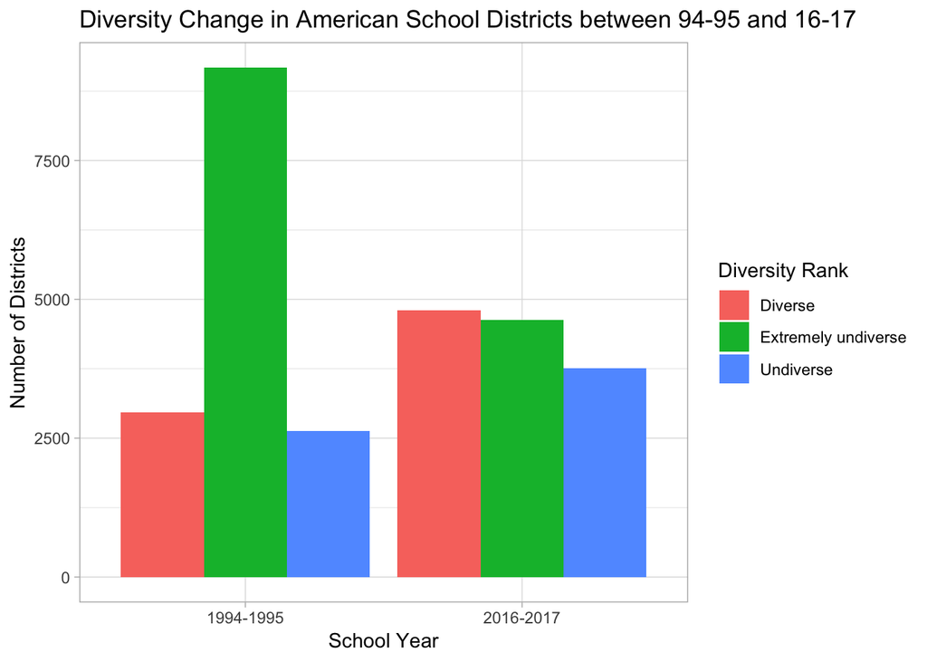

```r
diversity_year <- diversity2 %>%
  group_by(SCHOOL_YEAR, diverse) %>%
  summarise(count = n())

diversity_year %>%
  ggplot(aes(x = SCHOOL_YEAR, y = count, fill = diverse)) +
    geom_bar(stat = "identity", position = "dodge") +
    xlab("School Year") +
    ylab("Number of Districts") +
    ggtitle("Diversity Change in American School Districts between 94-95 and 16-17") +
    labs(fill = "Diversity Rank") +
    theme_light()
```

It appears that American school districts as a whole have become far more diverse in the past 20+ years. However, does this hold for every state?

### 2.6.2 Which States Have Best Improved the Diversity of Their School Districts?

```r
diversity_state <- diversity2 %>%
  group_by(SCHOOL_YEAR, diverse, ST) %>%
  summarise(count = n()) %>%
  ungroup() %>%
  complete(SCHOOL_YEAR, diverse, ST, fill = list(count = 0)) %>%
  spread(key = diverse, value = count)


#My method of spreading with multiple values

year94 <- diversity_state %>%
  filter(SCHOOL_YEAR == "1994-1995")
year16 <- diversity_state %>%
  filter(SCHOOL_YEAR == "2016-2017")
diversity_state2 <- inner_join(year94, year16, by = "ST")

diversity_state2 <- diversity_state2 %>%
  mutate(diverse_diff_mult = (`Diverse.y` / `Diverse.x`)) %>%
  mutate(undiverse_diff_mult = (`Undiverse.y` / `Undiverse.x`)) %>%
  mutate(ex_undiverse_diff_mult = (`Extremely undiverse.y` / `Extremely undiverse.x`)) %>%
  mutate(districts_94 = `Diverse.x` + `Extremely undiverse.x` + `Undiverse.x`) %>%
  mutate(districts_16 = `Diverse.y` + `Extremely undiverse.y` + `Undiverse.y`) %>%
  mutate(district_diff = districts_16 - districts_94) %>%
  mutate(district_diff_prop = district_diff / districts_94) %>%
  filter(`Diverse.y` >= 50)

top_diverse <- diversity_state2 %>%
  arrange(desc(diverse_diff_mult)) %>%
  head(10)

bottom_diverse <- diversity_state2 %>%
  arrange(desc(diverse_diff_mult)) %>%
  tail(10)
```

It is somewhat difficult to accurately analyze this data. When deciding how to rank which states had the greatest increases in school diversity, we must consider increase in our “diversity” total against decreases in our “undiverse” and “extremely undiverse” total, as well as the statistical signifance of the amount of districts in each state. Note that the amount of districts in 94-95 is not the same as the amount of districts in 16-17 either.

I decided to only consider an uptrend in the “diverse” category, as I noticed that many states which experienced great decreases in their “extremely undiverse category” simply had greater increases in their “undiverse category” too, illustrating that using these two similar columns only raises more complications. We also account for the significance of each state’s total present-day district count. States with fewer than 50 diverse districts in 2016 are filtered out.

#### 2.6.2.1 Most Diverse

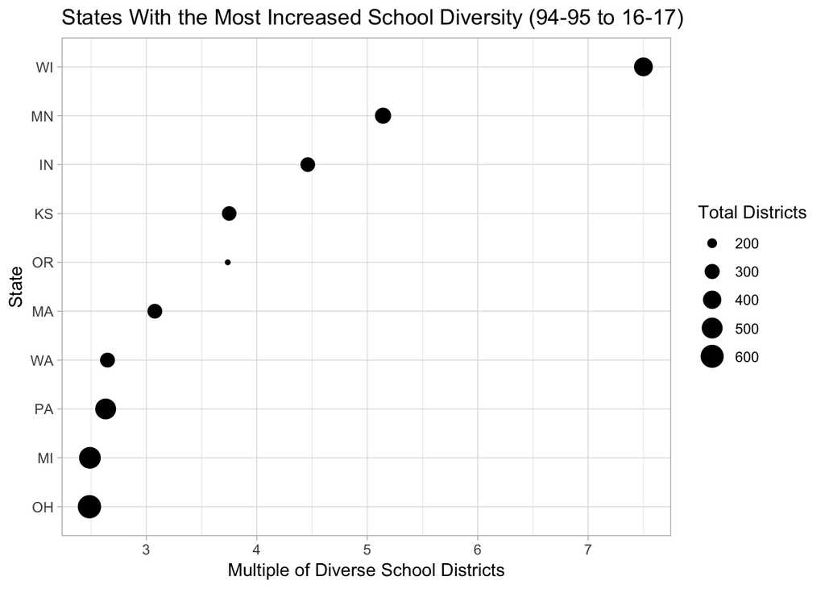

```r
top_diverse %>%
  ggplot(aes(diverse_diff_mult, fct_reorder(ST, diverse_diff_mult), size = districts_16)) +
    geom_point() +
    xlab("Multiple of Diverse School Districts") +
    ylab("State") +
    ggtitle("States With the Most Increased School Diversity (94-95 to 16-17)") +
    labs(size = "Total Districts") +
    theme_light()
```

We can see that most of the states with increased diversity in their school districts are in the midwest or north.

#### 2.6.2.2 Least Diverse

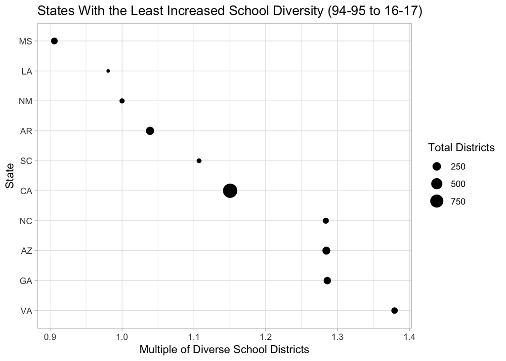

```r
bottom_diverse %>%
  ggplot(aes(diverse_diff_mult, fct_reorder(ST, diverse_diff_mult) %>% fct_rev(), size = districts_16)) +
    geom_point() +
    xlab("Multiple of Diverse School Districts") +
    ylab("State") +
    ggtitle("States With the Least Increased School Diversity (94-95 to 16-17)") +
    labs(size = "Total Districts") +
    theme_light()
```

Most of the school districts with the lowest increase in diversity are in the south, as Mississippi has actually experienced a decrease in diverse school districts. However, the most statistically significant point is California.

#### 2.6.2.3 Gain/Loss of Districts by State

We must also understand the extent to which different states have lost or gained school districts in between the two timeframes so we can determine more significance in the change of diversity from the previous graphs. Earlier in the EDA, we saw that the amount of overall school districts decreased from 1994-1995 to 2016-2017, so let’s see how this looks for each state.

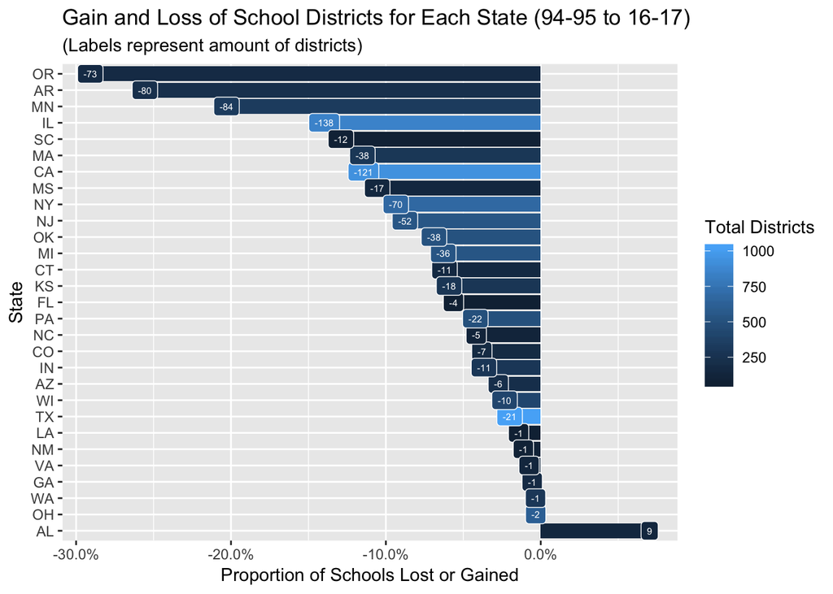

```r
diversity_state2 %>%
  mutate(ST = factor(ST, levels = ST[order(district_diff_prop)]) %>% fct_rev()) %>%
  ggplot(aes(ST, district_diff_prop, fill = districts_16)) +
    geom_bar(stat = "identity") +
    geom_label(aes(label = district_diff), color = "white", size = 2) +
    coord_flip() +
    ylab("Proportion of Schools Lost or Gained") +
    xlab("State") +
    scale_y_continuous(label = percent_format()) +
    ggtitle("Gain and Loss of School Districts for Each State (94-95 to 16-17)", subtitle = "(Labels represent amount of districts)") +
    labs(fill = "Total Districts")
```

### 2.6.3 How Do Developed Environments Affect Diversity?

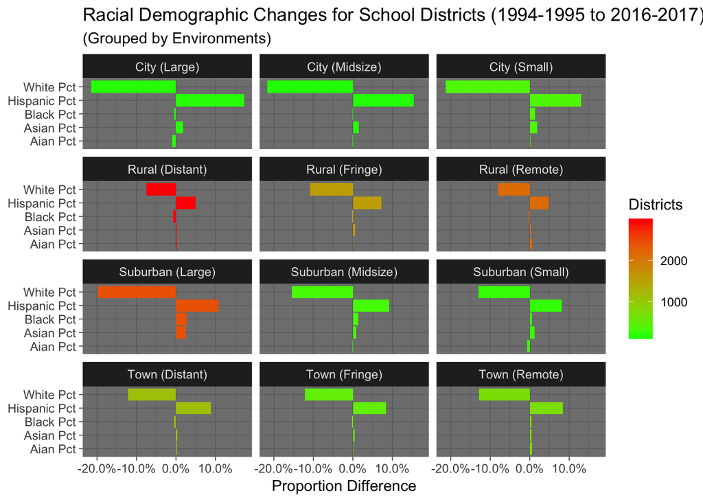

```r
counts <- diversity2 %>%
  filter(SCHOOL_YEAR == "1994-1995") %>%
  group_by(d_Locale_Txt) %>%
  summarise(count = n())

environments <- diversity2 %>%
  group_by(d_Locale_Txt, SCHOOL_YEAR) %>%
  summarise(white_pct = mean(White), hispanic_pct = mean(Hispanic), asian_pct = mean(Asian), black_pct = mean(Black), aian_pct = mean(AIAN), multi_pct = mean(Multi)) %>%
  filter(!is.na(d_Locale_Txt)) %>%
  melt() %>%
  spread(key = SCHOOL_YEAR, value = value) %>%
  mutate(prop_diff = (`2016-2017` - `1994-1995`) / 100) %>%
  filter(variable != "multi_pct") %>%
  left_join(counts, by = "d_Locale_Txt") %>%
  mutate(variable = str_replace(variable, "_", " ") %>% str_to_title(variable)) %>%
  mutate(d_Locale_Txt = str_replace(d_Locale_Txt, "-", " (") %>% paste0(")") %>% str_to_title(d_Locale_Txt))

?str_to_upper

environments %>%
  ggplot(aes(variable, prop_diff, fill = count)) +
    geom_bar(stat = "identity") +
    facet_wrap(~ d_Locale_Txt, nrow = 4) +
    coord_flip() +
    scale_y_continuous(label = percent_format()) +
    ylab("Proportion Difference") +
    xlab(NULL) +
    ggtitle("Racial Demographic Changes for School Districts (1994-1995 to 2016-2017)", subtitle = "(Grouped by Environments)") +
    labs(fill = "Districts") +
    scale_fill_gradient(low = "green", high = "red") +
    theme_dark()
```